# Final project 1

Libby Young

4/7/2020

# Data Summary:

Examine the statistics and values for each variable. Are any missing? Do any values need clarification or modification? If so, why and what did you do?

At first glance, we want to remove the entire ‘id’ column from this dataset because all it does is repeat the identifier from the numbered column that already identifies each point. We also removed the yearbuilt column becasue it was the same as age stardardized.

```r
Housing$id <- NULL
Housing$yearbuilt <- NULL
skim(Housing)
```

Data summary

| Name | Housing |
| --- | --- |
| Number of rows | 76 |
| Number of columns | 9 |
| _______________________ |  |
| Column type frequency: |  |
| character | 2 |
| numeric | 7 |
| ________________________ |  |
| Group variables | None |

**Variable type: character**

| skim_variable | n_missing | complete_rate | min | max | empty | n_unique | whitespace |
| --- | --- | --- | --- | --- | --- | --- | --- |
| status | 0 | 1 | 3 | 3 | 0 | 3 | 0 |
| elem | 0 | 1 | 4 | 6 | 0 | 6 | 0 |

**Variable type: numeric**

| skim_variable | n_missing | complete_rate | mean | sd | p0 | p25 | p50 | p75 | p100 | hist |
| --- | --- | --- | --- | --- | --- | --- | --- | --- | --- | --- |
| price | 0 | 1 | 285.80 | 60.33 | 155.50 | 242.75 | 276.00 | 336.75 | 450.0 | ▂▇▅▅▁ |
| size | 0 | 1 | 1.97 | 0.21 | 1.44 | 1.86 | 1.97 | 2.11 | 2.9 | ▂▇▆▁▁ |
| lot | 0 | 1 | 3.99 | 1.65 | 1.00 | 3.00 | 4.00 | 5.00 | 11.0 | ▃▇▁▁▁ |
| bath | 0 | 1 | 2.21 | 0.57 | 1.00 | 2.00 | 2.00 | 3.00 | 3.1 | ▁▁▇▁▃ |
| bedrooms | 0 | 1 | 3.45 | 0.74 | 2.00 | 3.00 | 3.00 | 4.00 | 6.0 | ▁▇▅▁▁ |
| agestandardized | 0 | 1 | -0.06 | 2.35 | -6.50 | -1.22 | -0.05 | 1.00 | 3.5 | ▂▁▆▇▅ |
| garagesize | 0 | 1 | 1.57 | 0.77 | 0.00 | 1.00 | 2.00 | 2.00 | 3.0 | ▂▂▁▇▁ |

```r
#changing the elementary school district and the status to be numeric
elem_numeric <- as.numeric(as.factor(Housing$elem))
status_numeric <- as.numeric(as.factor(Housing$status))
```

This ranks the two categorical variables (Elementary school district and Status: sold, pending sale, or active listing) and puts them into a numeric form.

# Exploratory Data Analysis

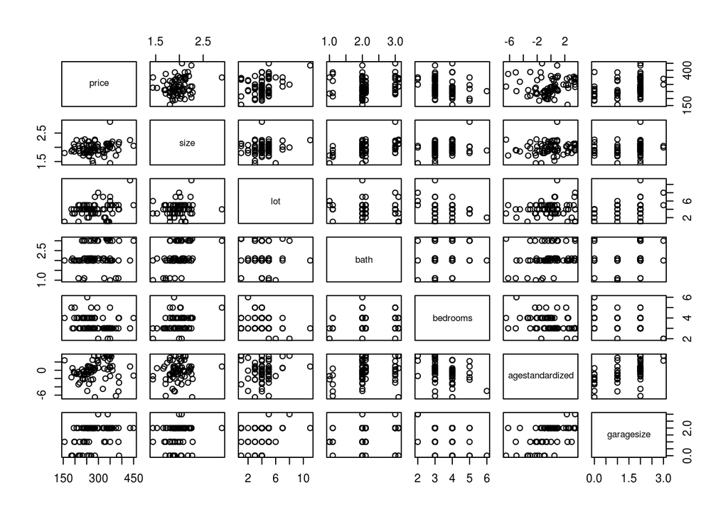

```r
pairs(Housing[,1:7])
```

Looking at these, it appears that size, lot, bath, age standardized, and garage size may have some kind of positive correlation. It also appears that bedrooms has a negative correlation. None of these correlations appear to be very strong and they all look like they have a lot of variation.

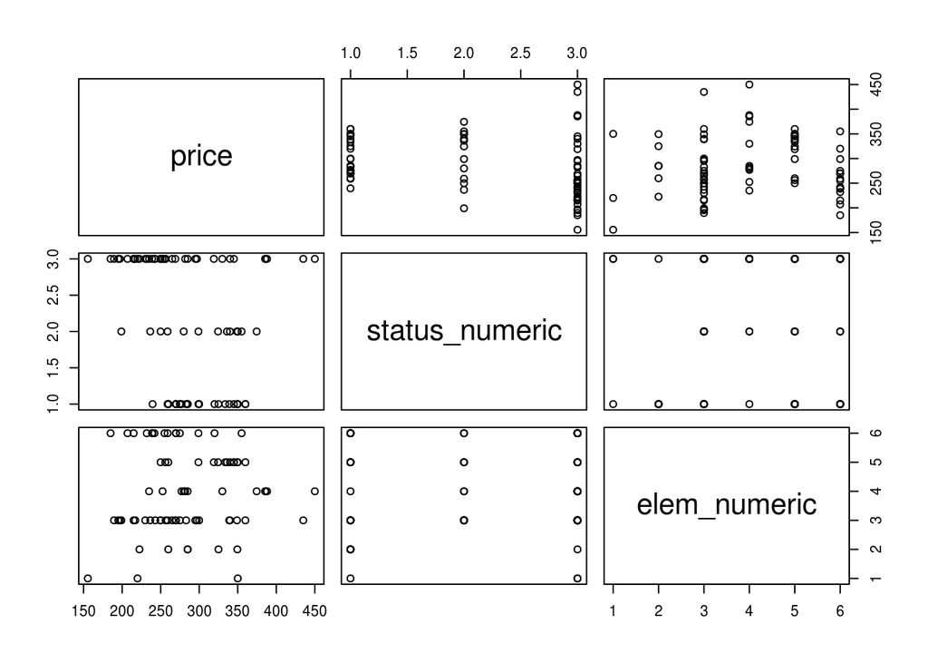

```r
#relationship with price for elem and status in numeric form
pairs(~price +status_numeric+elem_numeric, data = Housing)
```

These are the two categorical variables. Status appears to decrease the price as houses move from active listing, to pending, to sold. It also appears that certain elementary school districs have houses in a certain price range.

```r
Housing %>%
  select(price,size,lot,bath,bedrooms,agestandardized,garagesize) %>%
  cor()
```

```
##                      price       size         lot       bath   bedrooms
## price            1.0000000 0.20143783  0.24423228  0.1746578 -0.2861975
## size             0.2014378 1.00000000  0.04079199  0.4725406  0.2384530
## lot              0.2442323 0.04079199  1.00000000 -0.1709961 -0.2138298
## bath             0.1746578 0.47254061 -0.17099609  1.0000000  0.1468258
## bedrooms        -0.2861975 0.23845303 -0.21382977  0.1468258  1.0000000
## agestandardized  0.1541248 0.17656934 -0.03933975  0.3345239 -0.3631506
## garagesize       0.3583861 0.17315776  0.23581664  0.2017635 -0.4038039
##                 agestandardized garagesize
## price                0.15412476  0.3583861
## size                 0.17656934  0.1731578
## lot                 -0.03933975  0.2358166
## bath                 0.33452385  0.2017635
## bedrooms            -0.36315062 -0.4038039
## agestandardized      1.00000000  0.5371846
## garagesize           0.53718464  1.0000000
```

# Initial Modeling & Modeling Modification

Using your conclusions from the exploratory data analysis, build a regression model report your findings.

```r
#model with signifigant variables
m1 <- lm(price ~ lot + status + elem + garagesize + agestandardized:bedrooms, data=Housing)
summary(m1)
```

```
##
## Call:
## lm(formula = price ~ lot + status + elem + garagesize + agestandardized:bedrooms,
##     data = Housing)
##
## Residuals:
##     Min      1Q  Median      3Q     Max
## -98.974 -25.648  -3.504  28.482 100.432
##
## Coefficients:
##                          Estimate Std. Error t value Pr(>|t|)
## (Intercept)              201.5804    32.7630   6.153 5.28e-08 ***
## lot                       11.2766     3.6589   3.082  0.00302 **
## statuspen                -14.1211    16.9401  -0.834  0.40756
## statussld                -28.0497    13.9362  -2.013  0.04829 *
## elemcrest                 19.9800    33.8611   0.590  0.55720
## elemedge                  14.7652    29.3374   0.503  0.61646
## elemedison                95.0194    32.0688   2.963  0.00425 **
## elemharris                67.1824    30.8887   2.175  0.03328 *
## elemparker                -1.2943    29.9662  -0.043  0.96568
## garagesize                14.4472     9.6950   1.490  0.14101
## agestandardized:bedrooms   0.8191     0.9152   0.895  0.37408
## ---
## Signif. codes:  0 '***' 0.001 '**' 0.01 '*' 0.05 '.' 0.1 ' ' 1
##
## Residual standard error: 46.79 on 65 degrees of freedom
## Multiple R-squared:  0.4788, Adjusted R-squared:  0.3986
## F-statistic:  5.97 on 10 and 65 DF,  p-value: 2.385e-06
```

```r
vif(m1)
```

```
##                              GVIF Df GVIF^(1/(2*Df))
## lot                      1.253547  1        1.119619
## status                   1.478862  2        1.102762
## elem                     2.035636  5        1.073668
## garagesize               1.917885  1        1.384877
## agestandardized:bedrooms 2.041896  1        1.428949
```

The F-Statistic is low as is the R-squared value, which indicates some problems. The p-value is very low though, which is promising.

```r
#testing model with all variables except id, agestandardized, and yearbuilt since they showed little to no significance with related to price
m2<-lm(price~ lot + size:bath + elem + garagesize:agestandardized + status, data = Housing)
summary(m2)
```

```
##
## Call:
## lm(formula = price ~ lot + size:bath + elem + garagesize:agestandardized +
##     status, data = Housing)
##
## Residuals:
##     Min      1Q  Median      3Q     Max
## -87.305 -32.352  -0.479  28.082  98.071
##
## Coefficients:
##                            Estimate Std. Error t value Pr(>|t|)
## (Intercept)                187.6682    33.8418   5.545 5.75e-07 ***
## lot                         14.1656     3.4351   4.124 0.000108 ***
## elemcrest                   -0.2483    33.9686  -0.007 0.994190
## elemedge                     8.7736    28.8737   0.304 0.762205
## elemedison                  87.1905    30.3772   2.870 0.005529 **
## elemharris                  57.5666    30.8278   1.867 0.066361 .
## elemparker                 -11.7220    29.6132  -0.396 0.693522
## statuspen                  -14.6754    16.6667  -0.881 0.381822
## statussld                  -38.2213    12.9764  -2.945 0.004471 **
## size:bath                    8.2108     4.2800   1.918 0.059455 .
## garagesize:agestandardized   2.3584     1.7325   1.361 0.178140
## ---
## Signif. codes:  0 '***' 0.001 '**' 0.01 '*' 0.05 '.' 0.1 ' ' 1
##
## Residual standard error: 45.91 on 65 degrees of freedom
## Multiple R-squared:  0.4982, Adjusted R-squared:  0.421
## F-statistic: 6.454 on 10 and 65 DF,  p-value: 8.044e-07
```

```r
vif(m2)
```

```
##                                GVIF Df GVIF^(1/(2*Df))
## lot                        1.147727  1        1.071320
## elem                       1.740959  5        1.057009
## status                     1.315593  2        1.070978
## size:bath                  1.308297  1        1.143808
## garagesize:agestandardized 1.468613  1        1.211863
```

```r
m3 <- lm(price ~ agestandardized:bedrooms + status + garagesize:agestandardized + bath:size, data = Housing)
summary(m3)
```

```
##
## Call:
## lm(formula = price ~ agestandardized:bedrooms + status + garagesize:agestandardized +
##     bath:size, data = Housing)
##
## Residuals:
##     Min      1Q  Median      3Q     Max
## -105.55  -34.78  -11.23   30.13  164.89
##
## Coefficients:
##                             Estimate Std. Error t value Pr(>|t|)
## (Intercept)                258.69284   25.02755  10.336 9.92e-16 ***
## statuspen                    3.79379   19.98531   0.190   0.8500
## statussld                  -31.71614   15.80602  -2.007   0.0487 *
## agestandardized:bedrooms    -0.06888    1.24309  -0.055   0.9560
## agestandardized:garagesize   0.12669    2.88752   0.044   0.9651
## bath:size                    9.56334    5.21786   1.833   0.0711 .
## ---
## Signif. codes:  0 '***' 0.001 '**' 0.01 '*' 0.05 '.' 0.1 ' ' 1
##
## Residual standard error: 58.34 on 70 degrees of freedom
## Multiple R-squared:  0.1274, Adjusted R-squared:  0.06506
## F-statistic: 2.044 on 5 and 70 DF,  p-value: 0.08297
```

```r
vif(m3)
```

```
##                                GVIF Df GVIF^(1/(2*Df))
## status                     1.137579  2        1.032750
## agestandardized:bedrooms   2.423359  1        1.556714
## agestandardized:garagesize 2.526284  1        1.589429
## bath:size                  1.204167  1        1.097346
```

This has a bad p-value, low F-Stastic, and low R-squared

```r
#cubed
m4 <- lm(price ~ I((lot)^3) + I((size)^3) + I((bedrooms)^3) + I((garagesize)^3) + I((bath)^3) + status_numeric + elem_numeric, data = Housing)
summary(m4)
```

```
##
## Call:
## lm(formula = price ~ I((lot)^3) + I((size)^3) + I((bedrooms)^3) +
##     I((garagesize)^3) + I((bath)^3) + status_numeric + elem_numeric,
##     data = Housing)
##
## Residuals:
##     Min      1Q  Median      3Q     Max
## -82.696 -34.841  -8.887  31.687 156.701
##
## Coefficients:
##                    Estimate Std. Error t value Pr(>|t|)
## (Intercept)       267.27236   30.04112   8.897 5.18e-13 ***
## I((lot)^3)          0.10388    0.03923   2.648   0.0101 *
## I((size)^3)         2.91590    2.55980   1.139   0.2587
## I((bedrooms)^3)    -0.34518    0.20439  -1.689   0.0958 .
## I((garagesize)^3)   0.71960    1.47880   0.487   0.6281
## I((bath)^3)         1.27114    0.75466   1.684   0.0967 .
## status_numeric    -12.98038    7.15735  -1.814   0.0742 .
## elem_numeric        2.18207    4.37588   0.499   0.6196
## ---
## Signif. codes:  0 '***' 0.001 '**' 0.01 '*' 0.05 '.' 0.1 ' ' 1
##
## Residual standard error: 53.29 on 68 degrees of freedom
## Multiple R-squared:  0.2926, Adjusted R-squared:  0.2198
## F-statistic: 4.018 on 7 and 68 DF,  p-value: 0.0009815
```

```r
vif(m4)
```

```
##        I((lot)^3)       I((size)^3)   I((bedrooms)^3) I((garagesize)^3)
##          1.132803          1.350601          1.289718          1.387057
##       I((bath)^3)    status_numeric      elem_numeric
##          1.311083          1.096232          1.017256
```

The R-squared value is low here.

```r
#squared-rooted
m5 <- lm(price ~ I((lot)^.5) + I((size)^.5) + I((bedrooms)^.5) + I((garagesize)^.5) + I((bath)^.5) + status_numeric + elem_numeric, data = Housing)
summary(m5)
```

```
##
## Call:
## lm(formula = price ~ I((lot)^0.5) + I((size)^0.5) + I((bedrooms)^0.5) +
##     I((garagesize)^0.5) + I((bath)^0.5) + status_numeric + elem_numeric,
##     data = Housing)
##
## Residuals:
##     Min      1Q  Median      3Q     Max
## -100.53  -40.49  -10.52   34.62  165.91
##
## Coefficients:
##                     Estimate Std. Error t value Pr(>|t|)
## (Intercept)          116.815    129.638   0.901   0.3707
## I((lot)^0.5)          17.248     15.729   1.097   0.2767
## I((size)^0.5)        179.322    104.478   1.716   0.0906 .
## I((bedrooms)^0.5)    -80.019     38.184  -2.096   0.0398 *
## I((garagesize)^0.5)   13.101     15.202   0.862   0.3918
## I((bath)^0.5)         25.134     38.455   0.654   0.5156
## status_numeric       -12.163      7.717  -1.576   0.1196
## elem_numeric           1.544      4.589   0.336   0.7376
## ---
## Signif. codes:  0 '***' 0.001 '**' 0.01 '*' 0.05 '.' 0.1 ' ' 1
##
## Residual standard error: 55.33 on 68 degrees of freedom
## Multiple R-squared:  0.2376, Adjusted R-squared:  0.1591
## F-statistic: 3.027 on 7 and 68 DF,  p-value: 0.007879
```

```r
vif(m5)
```

```
##        I((lot)^0.5)       I((size)^0.5)   I((bedrooms)^0.5) I((garagesize)^0.5)
##            1.125261            1.508706            1.339306            1.434964
##       I((bath)^0.5)      status_numeric        elem_numeric
##            1.411651            1.182303            1.038008
```

# Conclusions:

Present your final model and diagnostic plots in support of that final model. In that presentation of the final model, comment on the R-squared value and its interpretation, give 95% confidence intervals for each of the β coefficients in your model, and illustrate your model’s use with a 95% confidence interval for the mean response and a 95% prediction interval for individual response for a hypothetical house of your choosing.

```r
Im5_Final<- lm(price ~ size:lot +  size:bath + status + elem, data = Housing)
summary(Im5_Final)
```

```
##
## Call:
## lm(formula = price ~ size:lot + size:bath + status + elem, data = Housing)
##
## Residuals:
##     Min      1Q  Median      3Q     Max
## -84.519 -32.955  -0.571  28.829  96.711
##
## Coefficients:
##             Estimate Std. Error t value Pr(>|t|)
## (Intercept)  202.843     31.394   6.461 1.45e-08 ***
## statuspen    -14.855     16.577  -0.896  0.37345
## statussld    -43.429     12.783  -3.397  0.00116 **
## elemcrest     -7.526     33.891  -0.222  0.82495
## elemedge       4.634     28.740   0.161  0.87240
## elemedison    78.586     29.940   2.625  0.01076 *
## elemharris    58.105     30.526   1.903  0.06134 .
## elemparker   -14.659     29.487  -0.497  0.62076
## size:lot       6.756      1.586   4.259 6.65e-05 ***
## size:bath      7.450      3.955   1.883  0.06405 .
## ---
## Signif. codes:  0 '***' 0.001 '**' 0.01 '*' 0.05 '.' 0.1 ' ' 1
##
## Residual standard error: 45.66 on 66 degrees of freedom
## Multiple R-squared:  0.4959, Adjusted R-squared:  0.4272
## F-statistic: 7.214 on 9 and 66 DF,  p-value: 3.253e-07
```

```r
vif(Im5_Final)
```

```
##               GVIF Df GVIF^(1/(2*Df))
## status    1.255883  2        1.058613
## elem      1.552846  5        1.044992
## size:lot  1.150247  1        1.072496
## size:bath 1.129381  1        1.062724
```

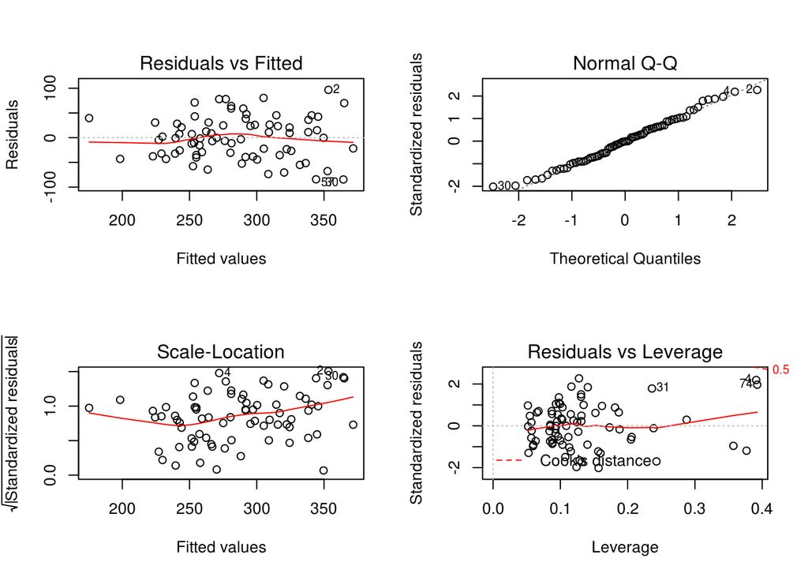

```r
par(mfrow = c(2, 2))
plot(Im5_Final)
```

```r
confint(Im5_Final)
```

```
##                   2.5 %    97.5 %
## (Intercept) 140.1616344 265.52337
## statuspen   -47.9528136  18.24261
## statussld   -68.9510428 -17.90630
## elemcrest   -75.1924998  60.14057
## elemedge    -52.7469759  62.01451
## elemedison   18.8084079 138.36314
## elemharris   -2.8419721 119.05274
## elemparker  -73.5322629  44.21503
## size:lot      3.5890608   9.92292
## size:bath    -0.4476469  15.34703
```

```r
#testing 95% confidence interval
predictionhouse <- data.frame(size = 2.080, lot = 2, bath = 2, status = 'pen', elem = 'edge')
predict(Im5_Final, predictionhouse, interval = "confidence")
```

```
##        fit      lwr      upr
## 1 251.7168 219.4834 283.9502
```

With 95% confidence, a house with size = 2.080, lot = 2, bath = 2, status = ‘pen’, elem = ‘edge’ would be between 219,483.40 dollars and 283,950.20 dollars, with the 50th percentile at 251,716.80 dollars. The actual price of this randomly selected house was 259,000.00 dollars. This not only fit within the confidence interval, but it was very near the 50th percentile. This model was sucessful.